# Analysing and visualising Data: By Hiten Naran

Now having spent a considerable amount of time cleaning data, I have been able to obtain a few observations and insights based on a series of questions against the cleaned data.

**Question 1:** Do we see a relationship between ratings and retweet counts?

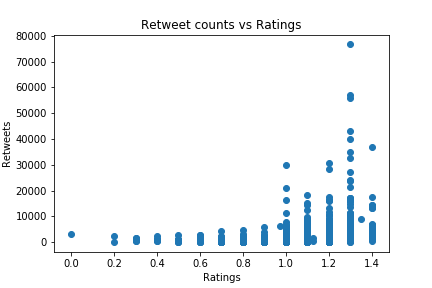

```python
from PIL import Image
pil_im = Image.open('retweet_ratings.png')
pil_im
```

**Conclusion:** The relationship between between retweets and ratings looks weak. Though when ratings exceed 1.0, it does seem like we see a higher volume of retweeted tweets. I wouldn't confidently declare a strong relationship betweet retweets and ratings

**Question 2:** Do we see a relationship between favorites and retweet counts?

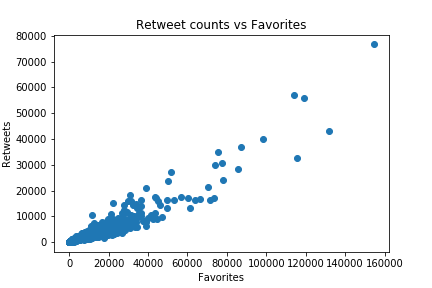

```python
pil_im_2 = Image.open('retweet_favorites.png')
pil_im_2
```

**Conclusion:** There looks to be a fairly strong relationship between retweets and favorites. From looking at this visual I would be confident in saying that the larger the number of retweets the more likely it is to generate a favorite. This is probably due to the fact that more people are seeing the tweet hence the greater likelyhood in a tweet being favorited.

**Question 3:** Is there a trend to be seen for retweet counts over time?

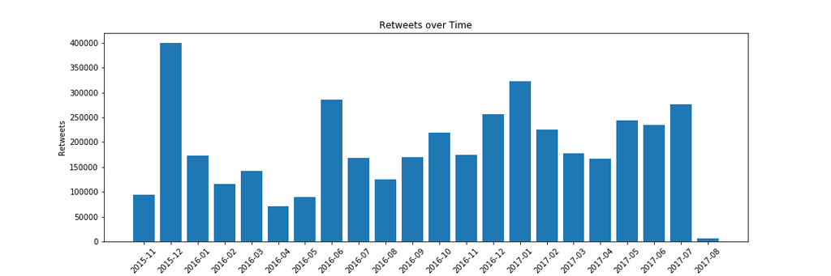

```python
pil_im_3 = Image.open('retweet_time.png')
pil_im_3
```

**Concluson:** There doesn't seem to be an obvious trend observed over time. The only standound stat is that 'December 2015' was the moth which generated the most cumulative number of retweets.

**Question 4:** What was the most rated Dog Type?

```python
import pandas as pd
pd.read_csv('dog_type_ratingcount.csv').head(10)
```

|  | type_dog | rating_count | percentage_rating_count |
| --- | --- | --- | --- |
| 0 | golden_retriever | 157 | 0.093564 |
| 1 | Labrador_retriever | 106 | 0.063170 |
| 2 | Pembroke | 95 | 0.056615 |
| 3 | Chihuahua | 91 | 0.054231 |
| 4 | pug | 62 | 0.036949 |
| 5 | toy_poodle | 50 | 0.029797 |
| 6 | chow | 48 | 0.028605 |
| 7 | Pomeranian | 42 | 0.025030 |
| 8 | Samoyed | 41 | 0.024434 |
| 9 | malamute | 33 | 0.019666 |

**Conclusion:** It looks like 'golder_retreiver' and 'Labrador_retreiver' were the most rated dog types, featuring across ~ 15.6% of tweets.